# CSC 587 HW 2

Daniel R. Getty

2024-02-06

## Set r Environment

```r
knitr::opts_chunk$set(echo = TRUE, message = TRUE)
# directory
dir <- 'G:\\My Drive\\H Drive\\Course Work\\CERG-Data Science\\CSC_587_Advanced_Data_Mining\\HW\\HW2_DataMining_with_py'
# Set the working directory.
setwd(dir)
# Print the working directory.
getwd()
```

```
## [1] "G:/My Drive/H Drive/Course Work/CERG-Data Science/CSC_587_Advanced_Data_Mining/HW/HW2_DataMining_with_Py"
```

```r
# load ggplot2 package
library(ggplot2)
# load ggplot2 package
library(ggplot2)
# load dplyr package
library(dplyr)
# load tidyr package
library(tidyr)
```

## Set py Environment

```python
import os
import pandas as pd
import numpy as np
import math
```

## Homework 1

1: Find the distance between objects 1 and 3 by using the formula provided on the slides. Notice that we have mixed type of attributes.

```python
# Create a dictionary of data
data1py = {
    'ObjectIdentifier': [1, 2, 3, 4],
    'test1.nominal': ['A', 'B', 'C', 'A'],
    'test2.ordinal': ['excellent', 'fair', 'good', 'excellent'],
    'test3.numeric': [45, 22, 64, 28]
}
# Create a DataFrame from the dictionary

type(data1py)
```

```
## <class 'dict'>
```

```python
v1a = data1py['test3.numeric'][0]
v1b = data1py['test3.numeric'][2]
v1c = data1py['ObjectIdentifier']
v1d = data1py['test3.numeric']
print ('v1a =',v1a)
```

```
## v1a = 45
```

```python
print ('v1b =',v1b)
```

```
## v1b = 64
```

```python
print ('v1c =',v1c)
```

```
## v1c = [1, 2, 3, 4]
```

```python
print ('v1d =',v1d)
```

```
## v1d = [45, 22, 64, 28]
```

```python
manhattan = abs(v1a - v1b)
euclidian = math.sqrt((v1a - v1b) ** 2)
print('Manhattan =',manhattan)
```

```
## Manhattan = 19
```

```python
print('Euclidian =',euclidian)
```

```
## Euclidian = 19.0
```

2: Write a program in any language which can compute Manhattan and Euclidean distances between any two given vectors with any length. You can pass the length to your function, but please don’t limit the dimension to 2. You can test your function on vectors you fill in your code without asking user input.

```python
def distance(v1, v2):
    # Manhattan distance is taxicab distance, the sum of the absolute differences between the coordinates of the points
    manhatten = sum(abs(a1 - b1) for a1, b1 in zip(v1, v2))
    # Euclidean distance is strait line distance
    euclidian = math.sqrt(sum((a2 - b2) ** 2 for a2, b2 in zip(v1, v2)))
    # Hamming distance is used for categorical data
    hamming = sum(a3 != b3 for a3, b3 in zip(v1, v2))
    # Cosine distance is used to find similarity between data points
    cosine = sum(a4 * b4 for a4, b4 in zip(v1, v2)) / (math.sqrt(sum(a4 ** 2 for a4 in v1)) * math.sqrt(sum(b4 ** 2 for b4 in v2)))
    print("Manhattan distance:", manhatten)
    print("Euclidean distance:", euclidian)
    print("Hamming distance:", hamming)
    print("Cosine distance:", cosine)

# Define two vectors
v1 = v1c
v2 = v1d

# Call  the function
dis = distance(v1, v2)
```

```
## Manhattan distance: 149
## Euclidean distance: 81.44323176298937
## Hamming distance: 4
## Cosine distance: 0.8347166756106098
```

3: In the table below, determine whether passing a class has a dependency on attendance by using Chi-square test. Please refer to the formula in the slides. (For the expected value for each cell, multiply the total counts in the rows and columns of the cell and divide by total count. For example: Expected value for Attended-Pass=33*31/54 = 18.94. You can scan and submit your handwritten calculation)

```python
# Create a DataFrame
df = pd.DataFrame({
    'Attended': [25, 6, 31],
    'Skipped': [8, 15, 23],
}, index=['Passed', 'Failed', 'Total'])

# Calculate row and column totals
row_totals = df.loc[:, 'Attended':'Skipped'].sum(axis=1)
col_totals = df.loc['Total', :]

# Calculate grand total
grand_total = df.loc['Total', 'Attended':'Skipped'].sum()

# Calculate expected values for each cell
expected_values = pd.DataFrame()
for row in ['Passed', 'Failed']:
    for col in ['Attended', 'Skipped']:
        expected_values.loc[row, col] = (row_totals[row] * col_totals[col]) / grand_total
expected_values = round(expected_values,2)

# print the DataFrames
print("The DataFrame is:")
```

```
## The DataFrame is:
```

```python
print(df, '\n')
```

```
##         Attended  Skipped
## Passed        25        8
## Failed         6       15
## Total         31       23
```

```python
print("The Expected Values are:")
```

```
## The Expected Values are:
```

```python
print(expected_values)
```

```
##         Attended  Skipped
## Passed     18.94    14.06
## Failed     12.06     8.94
```

4: In R, there is a built-in data frame called mtcars. Please calculate the correlation between mpg and wt attributes of mtcars by using cor() function. Then generate scatter plot based on these two attributes. Your scatter plot should be like the one below. You don’t need to submit the image, but R script should be submitted

```r
# Load the mtcars data
data(mtcars)
# Calculate the correlation between mpg and wt
cor(mtcars$mpg, mtcars$wt)
```

```
## [1] -0.8676594
```

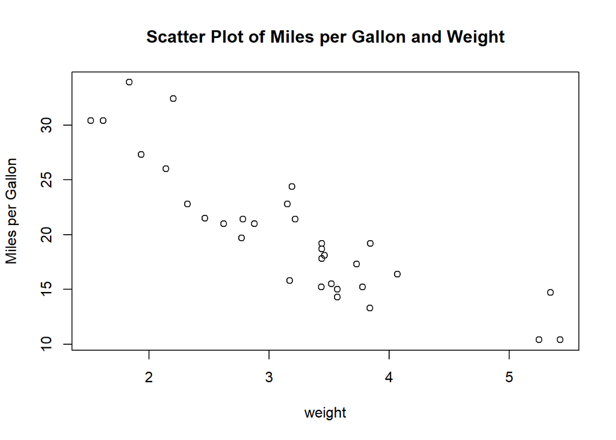

```r
# Generate scatter plot
plot(mtcars$wt, mtcars$mpg, xlab='weight', ylab='Miles per Gallon', main='Scatter Plot of Miles per Gallon and Weight')
```

5: Grad Students Only Write an R or Python script which removes or drops the columns which have more than 75% missing values. Then it should replace the missing values in the remaining columns with the median value of the 1existing values of that particular column. Download metabolite.csv from Google Drive and use this data set to test your code. Please check the end of this document for some useful R examples and hints.

```r
# Load the metabolite data
data_file <- file.path('metabolite.csv')
# Build data frame from the data set.
metabolite <-read.csv(data_file, header = TRUE, sep = ',')
# Print the data frame.
#glimpse(metabolite)
head(metabolite)
```

|  | Label | Phe | Pro | Ser | Thr | ADMA | alpha.AAA | c4.OH.Pro | Carnosine | Creatinine | DOPA | Dopamine | Histamine | Kynurenine | Met.SO | Nitro.Tyr | PEA | Putrescine | Sarcosine | Serotonin | Spermidine | Spermine | t4.OH.Pro | Taurine | SDMA | C0 | C10 | C10.1 | C10.2 | … |
| --- | --- | --- | --- | --- | --- | --- | --- | --- | --- | --- | --- | --- | --- | --- | --- | --- | --- | --- | --- | --- | --- | --- | --- | --- | --- | --- | --- | --- | --- | --- |
| 1 | Alzheimer | 72.8 | 166 | 170 | 282 | 1.15 | 0.760 | 0.236 | 1.270 | 49.9 | 0.265 | 0.233 | 0.225 | 5.21 | 0.526 | 0.027 | NA | 0.068 | 17.8 | 0.147 | 0.188 | NA | 24.0 | 125 | 1.13 | 18.2 | 0.059 | 0.312 | 0.038 | … |
| 2 | Alzheimer | 93.4 | 138 | 142 | 217 | 1.05 | 0.929 | 0.189 | 1.350 | 48.8 | 0.252 | NA | 0.211 | 5.44 | 0.387 | NA | NA | 0.087 | 20.2 | 0.231 | 0.233 | NA | 29.3 | 120 | 1.65 | 17.0 | 0.051 | 0.288 | 0.039 | … |
| 3 | Alzheimer | 68.6 | 161 | 158 | 208 | 1.00 | 0.620 | 0.198 | 0.998 | 30.4 | 0.268 | NA | 0.217 | 5.20 | 0.651 | NA | NA | 0.260 | 14.4 | 0.196 | 0.384 | NA | 20.9 | 139 | 1.57 | 12.6 | 0.083 | 0.357 | 0.054 | … |
| 4 | Alzheimer | 94.1 | 129 | 162 | 201 | 1.10 | 0.795 | NA | 0.675 | 80.1 | 0.264 | 0.234 | 0.209 | 5.80 | 0.389 | NA | NA | 0.110 | 18.7 | 0.255 | 0.353 | NA | 23.1 | 159 | 1.34 | 23.5 | 0.071 | 0.317 | 0.040 | … |
| 5 | Alzheimer | 79.8 | 126 | 115 | 199 | 1.24 | 1.360 | NA | 1.280 | 60.5 | 0.271 | 0.231 | 0.210 | 4.46 | 0.466 | NA | NA | 0.118 | 22.5 | 0.390 | 0.473 | NA | 26.9 | 149 | 1.24 | 13.6 | 0.139 | 0.472 | 0.074 | … |
| 6 | Alzheimer | 82.5 | 167 | 173 | 333 | 1.35 | 1.150 | NA | 1.010 | 24.0 | 0.275 | NA | 0.212 | 7.01 | 0.417 | NA | NA | 0.262 | 30.8 | 0.140 | 0.856 | 1.28 | 26.0 | 379 | 1.44 | 26.7 | 0.058 | 0.238 | 0.042 | … |

```r
# Remove columns with more than 75% missing values by keeping the columns with less than 75% missing values
clean_metabolite <- metabolite[, colSums(is.na(metabolite)) <= 0.75 * nrow(metabolite)]
head(clean_metabolite)
```

|  | Label | Phe | Pro | Ser | Thr | ADMA | alpha.AAA | c4.OH.Pro | Carnosine | Creatinine | DOPA | Dopamine | Histamine | Kynurenine | Met.SO | Putrescine | Sarcosine | Serotonin | Spermidine | t4.OH.Pro | Taurine | SDMA | C0 | C10 | C10.1 | C10.2 | C12 | C12.DC | C12.1 | … |
| --- | --- | --- | --- | --- | --- | --- | --- | --- | --- | --- | --- | --- | --- | --- | --- | --- | --- | --- | --- | --- | --- | --- | --- | --- | --- | --- | --- | --- | --- | --- |
| 1 | Alzheimer | 72.8 | 166 | 170 | 282 | 1.15 | 0.760 | 0.236 | 1.270 | 49.9 | 0.265 | 0.233 | 0.225 | 5.21 | 0.526 | 0.068 | 17.8 | 0.147 | 0.188 | 24.0 | 125 | 1.13 | 18.2 | 0.059 | 0.312 | 0.038 | 0.030 | 0.042 | 0.290 | … |
| 2 | Alzheimer | 93.4 | 138 | 142 | 217 | 1.05 | 0.929 | 0.189 | 1.350 | 48.8 | 0.252 | NA | 0.211 | 5.44 | 0.387 | 0.087 | 20.2 | 0.231 | 0.233 | 29.3 | 120 | 1.65 | 17.0 | 0.051 | 0.288 | 0.039 | 0.038 | 0.038 | 0.265 | … |
| 3 | Alzheimer | 68.6 | 161 | 158 | 208 | 1.00 | 0.620 | 0.198 | 0.998 | 30.4 | 0.268 | NA | 0.217 | 5.20 | 0.651 | 0.260 | 14.4 | 0.196 | 0.384 | 20.9 | 139 | 1.57 | 12.6 | 0.083 | 0.357 | 0.054 | 0.032 | 0.048 | 0.302 | … |
| 4 | Alzheimer | 94.1 | 129 | 162 | 201 | 1.10 | 0.795 | NA | 0.675 | 80.1 | 0.264 | 0.234 | 0.209 | 5.80 | 0.389 | 0.110 | 18.7 | 0.255 | 0.353 | 23.1 | 159 | 1.34 | 23.5 | 0.071 | 0.317 | 0.040 | 0.045 | 0.048 | 0.275 | … |
| 5 | Alzheimer | 79.8 | 126 | 115 | 199 | 1.24 | 1.360 | NA | 1.280 | 60.5 | 0.271 | 0.231 | 0.210 | 4.46 | 0.466 | 0.118 | 22.5 | 0.390 | 0.473 | 26.9 | 149 | 1.24 | 13.6 | 0.139 | 0.472 | 0.074 | 0.056 | 0.079 | 0.394 | … |
| 6 | Alzheimer | 82.5 | 167 | 173 | 333 | 1.35 | 1.150 | NA | 1.010 | 24.0 | 0.275 | NA | 0.212 | 7.01 | 0.417 | 0.262 | 30.8 | 0.140 | 0.856 | 26.0 | 379 | 1.44 | 26.7 | 0.058 | 0.238 | 0.042 | 0.039 | 0.035 | 0.196 | … |

```r
# Replace missing values with the median value of the existing values of that particular column
clean_metabolite2 <- clean_metabolite %>% mutate_all(~ifelse(is.na(.x), median(.x, na.rm = TRUE), .x))
glimpse(clean_metabolite2)
```

```
## Rows: 69
## Columns: 188
## $ Label              <chr> "Alzheimer", "Alzheimer", "Alzheimer", "Alzheimer",…
## $ Phe                <dbl> 72.8, 93.4, 68.6, 94.1, 79.8, 82.5, 69.7, 83.6, 73.…
## $ Pro                <dbl> 166.0, 138.0, 161.0, 129.0, 126.0, 167.0, 95.6, 119…
## $ Ser                <dbl> 170, 142, 158, 162, 115, 173, 143, 135, 145, 174, 1…
## $ Thr                <int> 282, 217, 208, 201, 199, 333, 244, 268, 307, 269, 2…
## $ ADMA               <dbl> 1.150, 1.050, 1.000, 1.100, 1.240, 1.350, 0.991, 1.…
## $ alpha.AAA          <dbl> 0.760, 0.929, 0.620, 0.795, 1.360, 1.150, 0.927, 0.…
## $ c4.OH.Pro          <dbl> 0.236, 0.189, 0.198, 0.198, 0.198, 0.198, 0.184, 0.…
## $ Carnosine          <dbl> 1.270, 1.350, 0.998, 0.675, 1.280, 1.010, 0.702, 0.…
## $ Creatinine         <dbl> 49.9, 48.8, 30.4, 80.1, 60.5, 24.0, 41.6, 30.6, 39.…
## $ DOPA               <dbl> 0.265, 0.252, 0.268, 0.264, 0.271, 0.275, 0.260, 0.…
## $ Dopamine           <dbl> 0.233, 0.231, 0.231, 0.234, 0.231, 0.231, 0.231, 0.…
## $ Histamine          <dbl> 0.225, 0.211, 0.217, 0.209, 0.210, 0.212, 0.211, 0.…
```

[output cut: 175 more lines]

6: Grad Students Only Please apply Principal Component Analysis (PCA) on the processed metabolites data and create a scatter plot by using first two principal components in which points are colored based on the Label column. Please submit your code along with your figure in the same file.

(If you are going to use R, you may need to use which(), is.na() functions and consider excluding those columns by name. For that purpose you may investigate %in% and -c(…) type of operations. You can also see examples of subsetting a dataframe below with their outputs. It’s also recommended to check tidyverse library.)

```r
# Apply PCA on the processed metabolites data
pca_metabolite <- clean_metabolite2 %>% select(Phe ,Pro,) %>% prcomp(scale = TRUE)
print(pca_metabolite)
```

```
## Standard deviations (1, .., p=2):
## [1] 1.1391092 0.8381111
##
## Rotation (n x k) = (2 x 2):
##           PC1        PC2
## Phe 0.7071068  0.7071068
## Pro 0.7071068 -0.7071068
```

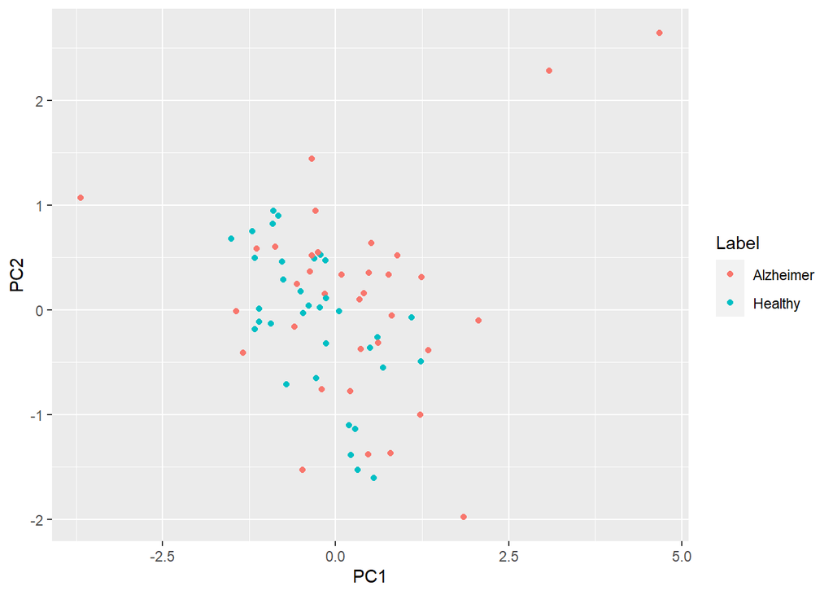

```r
# Create a scatter plot by using first two principal components
pca_metabolite_df <- as.data.frame(pca_metabolite$x)
pca_metabolite_df$Label <- clean_metabolite2$Label
ggplot(data = pca_metabolite_df, aes(x = PC1, y = PC2, color = Label)) + geom_point()
```